# Analyzing Smite Data for Fun and Profit*

[figure not shown]

# *What is Smite?*

Chances are, if you're reading this, you know what Smite is, and are, most likely, at least somewhat familiar with it. If not, however; here's a a brief overview, courtesy of Wikipedia.

> Smite is a free-to-play, third-person multiplayer online battle arena (MOBA) video game developed and published by Hi-Rez Studios for Microsoft Windows, macOS, PlayStation 4, Nintendo Switch and Xbox One.[5] In Smite, players control a god, goddess, or other mythological figure and take part in team based combat, using abilities and tactics against other player-controlled gods and non-player-controlled minions. The game has multiple player versus player modes, many playable characters, and has a successful eSports scene with multiple tournaments, including the annual Smite World Championship which has a million dollar prize pool.

I've been playing Smite for about 3 years now and frankly just love the game, so it has been very exciting to have the opportunity to dive deeper into the underlying data.

# Getting started

We start by importing the tools we are going to use for this project. This inlcudes Pandas, Numpy, Scikitlearn, and Matplotlib.

### About the data

- Our data set contains ~6,000 matches of (casual Conquest mode) worth of data, broken up into individual player performances (these will be refferred to as *player matches*), totalling ~60,000 rows of data.
- The data was collected from Hi-Rez Studios' official API via a Ruby on Rails application I developed, available [here](https://github.com/meichsteadt/smite_api) (more info on the API can be found [here](https://www.hirezstudios.com/wp-content/themes/hi-rez-studios/pdf/smite-api-developer-guide.pdf))
- The data is stored in a CSV file that we are importing below as `csv`
- The Hi-Rez API allows a player to hide their information in order to preserve their privacy. These players have been assigned to 'hidden player'. There are ~4400 of these data points.

```python
import pandas as pd
import numpy as np
from sklearn.metrics import accuracy_score
from sklearn.model_selection import train_test_split
from sklearn.tree import DecisionTreeClassifier
from sklearn.preprocessing import StandardScaler
from sklearn.cluster import KMeans
from itertools import cycle, islice

# import utils
import matplotlib.pyplot as plt
from pandas.plotting import parallel_coordinates
%matplotlib inline

pd.options.display.max_rows = 500
pd.options.display.max_columns = 200
pd.options.display.float_format = '{:,}'.format
dtype = {'damage_mitigated': np.int32, 'damage_player': np.int32, 'minutes': np.int32, 'god_name': np.unicode_, 'account_level': np.int32}
csv = pd.read_csv("./player_match_output.csv",thousands=",", dtype=dtype)
```

## Looking at the data

Below are some descriptive statistics of the data. Obviously some of these will be useless information (i.e. the mean ID of a game), but some of this can help you get a decent sense for the game.

For example:

Looking at the distribution of `account_level`, 75% of players are level 65+. This demonstrates that Smite is a game played by a dedicated user base instead of a stream of new users.

You can also get a sense of what occurs within a match. What a normal number of kills, deaths, gold per minute, assists, etc. might look like.

```python
csv.describe().round(4)
```

|  | id | match_id | player_id | account_level | assists | damage_mitigated | damage_player | damage_taken | deaths | final_match_level | god_id | gold_earned | gold_per_minute | healing | kills_fire_giant | kills_first_blood | kills_gold_fury | kills_phoenix | kills_player | mastery_level | minutes | objective_assists | structure_damage | surrendered | time_in_match_seconds | towers_destroyed | wards_placed | smite_match_id | win_status | … |
| --- | --- | --- | --- | --- | --- | --- | --- | --- | --- | --- | --- | --- | --- | --- | --- | --- | --- | --- | --- | --- | --- | --- | --- | --- | --- | --- | --- | --- | --- | --- |
| count | 60,080.0 | 60,080.0 | 60,080.0 | 60,080.0 | 60,080.0 | 60,080.0 | 60,080.0 | 60,080.0 | 60,080.0 | 60,080.0 | 60,080.0 | 60,080.0 | 60,080.0 | 60,080.0 | 60,080.0 | 60,080.0 | 60,080.0 | 60,080.0 | 60,080.0 | 60,080.0 | 60,080.0 | 60,080.0 | 60,080.0 | 60,080.0 | 60,080.0 | 60,080.0 | 60,080.0 | 60,080.0 | 60,080.0 | … |
| mean | 241,659.0103 | 32,151.5043 | 24,094.1949 | 94.8392 | 6.9507 | 13,529.9511 | 15,676.7636 | 20,229.5321 | 5.3972 | 16.3741 | 2,141.0248 | 12,959.9762 | 491.6609 | 630.3174 | 0.0779 | 0.1 | 0.1319 | 0.1442 | 5.3417 | 55.4482 | 26.0198 | 2.6259 | 1,300.9559 | 0.5328 | 1,589.6779 | 0.5156 | 1.8437 | 186,346,456.8813 | 0.5 | … |
| std | 17,845.2239 | 9,081.4583 | 16,398.7881 | 40.7259 | 5.9091 | 15,725.3147 | 12,089.6693 | 12,674.7034 | 3.8332 | 4.3302 | 553.4477 | 5,515.9821 | 73.7796 | 2,065.756 | 0.2919 | 0.3 | 0.3902 | 0.4512 | 5.0628 | 33.7816 | 10.8005 | 2.851 | 1,816.3696 | 0.4989 | 648.568 | 0.7814 | 3.5545 | 328,296.61 | 0.5 | … |
| min | 77,050.0 | 13,361.0 | 1,361.0 | 1.0 | 0.0 | 0.0 | 0.0 | 0.0 | 0.0 | 1.0 | 1,649.0 | 909.0 | 180.0 | 0.0 | 0.0 | 0.0 | 0.0 | 0.0 | 0.0 | 0.0 | 5.0 | 0.0 | 0.0 | 0.0 | 301.0 | 0.0 | 0.0 | 186,156,200.0 | 0.0 | … |
| 25% | 226,930.75 | 34,503.75 | 8,458.75 | 65.0 | 2.0 | 3,783.0 | 6,358.75 | 10,033.75 | 2.0 | 13.0 | 1,797.0 | 8,470.0 | 441.0 | 0.0 | 0.0 | 0.0 | 0.0 | 0.0 | 2.0 | 23.0 | 17.0 | 0.0 | 17.0 | 0.0 | 1,070.75 | 0.0 | 0.0 | 186,172,969.75 | 0.0 | … |
| 50% | 241,950.5 | 36,005.5 | 23,222.0 | 103.0 | 6.0 | 8,114.0 | 12,821.5 | 18,290.5 | 5.0 | 18.0 | 1,966.0 | 12,666.5 | 489.0 | 0.0 | 0.0 | 0.0 | 0.0 | 0.0 | 4.0 | 58.0 | 26.0 | 2.0 | 629.0 | 1.0 | 1,581.0 | 0.0 | 0.0 | 186,191,429.5 | 0.5 | … |
| 75% | 256,970.25 | 37,507.25 | 41,378.0 | 127.0 | 10.0 | 16,396.0 | 22,022.0 | 27,923.25 | 8.0 | 20.0 | 2,136.0 | 16,689.25 | 540.0 | 375.0 | 0.0 | 0.0 | 0.0 | 0.0 | 8.0 | 91.0 | 33.0 | 4.0 | 1,768.0 | 1.0 | 2,034.0 | 1.0 | 2.0 | 186,210,001.25 | 1.0 | … |
| max | 271,990.0 | 39,012.0 | 49,482.0 | 160.0 | 59.0 | 213,022.0 | 154,757.0 | 136,837.0 | 35.0 | 20.0 | 3,558.0 | 47,077.0 | 853.0 | 58,813.0 | 4.0 | 1.0 | 4.0 | 7.0 | 56.0 | 98.0 | 89.0 | 22.0 | 20,101.0 | 1.0 | 5,344.0 | 5.0 | 172.0 | 187,021,826.0 | 1.0 | … |

## How do you win?

The goal in Smite is to destroy the other teams' defenses and destroy their *Titan*. In order to do this, you must work as a team to eliminate the enemy team, computer controlled minions, and other objectives in order to get gold and gain experience.

Below, we are going to look at some of the attributes that contribute to winning a game. But first, let's define these attributes.

- **win_status**: Whether or not the player_match resulted in a win (1=win, 0=loss)
- **gold_per_minute**: How much gold a player earns per minute. A good metric for determining how well a player is "farming".
- **objective_assists**: How many times a player was involved in taking objectives.
- **kda**: Kills Death Assists ratio. Commonly used as a metric for player performace (however it has its limitations).  
  The formula is `(Kills + Assists/2)/Deaths`
- **kd**: A simpler metric for player performance.  
  `Kills/Deaths`
- **assists**: An assists is earned when you help kill an enemy player.
- **kills_player**: The number of times you killed an enemy player.
- **kills_participation**: The percentage of your teams total kills that you were a part of  
  `(kills_player + assists)/Team's total kills`.
- **deaths**: The number of times your character died.

Below, we look at each of these statistics and how they correlate to each other. Particularly, we are looking at how they correlate to **win_status**. This will give us a picture of what influences wins.

```python
key_metrics = ["win_status", "kills_player", "kda", "assists", "kd", "gold_per_minute", "deaths", "objective_assists", "kill_participation"]
csv[key_metrics].corr().sort_values(by="win_status", ascending=False)
```

|  | win_status | kills_player | kda | assists | kd | gold_per_minute | deaths | objective_assists | kill_participation |
| --- | --- | --- | --- | --- | --- | --- | --- | --- | --- |
| win_status | 1.0 | 0.23803389509418482 | 0.4485948892284536 | 0.2949241772132657 | 0.3739568655786218 | 0.553438972145409 | -0.3113177153917803 | 0.46181753752656884 | 0.06975056787346286 |
| gold_per_minute | 0.553438972145409 | 0.5254851939359578 | 0.5631260689355531 | 0.13708723716315968 | 0.5836911819595593 | 1.0 | -0.36009058067085 | 0.3603994409104403 | 0.3566466908411925 |
| objective_assists | 0.46181753752656884 | 0.47764155348906806 | 0.3181786803886083 | 0.6094872207017173 | 0.23734083066961228 | 0.3603994409104403 | 0.135384118606584 | 1.0 | 0.234510713252786 |
| kda | 0.4485948892284536 | 0.44999881206867715 | 1.0 | 0.24704108295708924 | 0.9363744017202117 | 0.5631260689355531 | -0.4361398216266103 | 0.3181786803886083 | 0.34625699416654443 |
| kd | 0.3739568655786218 | 0.5340135620107792 | 0.9363744017202117 | 0.06259950692863546 | 1.0 | 0.5836911819595593 | -0.3840585634127393 | 0.23734083066961228 | 0.31415693155137914 |
| assists | 0.2949241772132657 | 0.3467982330083652 | 0.24704108295708924 | 1.0 | 0.06259950692863546 | 0.13708723716315968 | 0.28596562343639376 | 0.6094872207017173 | 0.41691056046253605 |
| kills_player | 0.23803389509418482 | 1.0 | 0.44999881206867715 | 0.3467982330083652 | 0.5340135620107792 | 0.5254851939359578 | 0.19726630753056537 | 0.47764155348906806 | 0.4915120339066707 |
| kill_participation | 0.06975056787346286 | 0.4915120339066707 | 0.34625699416654443 | 0.41691056046253605 | 0.31415693155137914 | 0.3566466908411925 | 0.05349220925244342 | 0.234510713252786 | 1.0 |
| deaths | -0.3113177153917803 | 0.19726630753056537 | -0.4361398216266103 | 0.28596562343639376 | -0.3840585634127393 | -0.36009058067085 | 1.0 | 0.135384118606584 | 0.05349220925244342 |

As you can see **gold_per_minute** has the strongest correlation. Meanwhile, **deaths** has a negative correlation, which if you play Smite, makes a lot of sense. The more you die, the less likely you are to win.

Something that is interesting, however, is the unstabilizing effect match duration has on these metrics. Let's examine that further.

Below you'll find two different rows of data. The `under_30` row containing data from games 30 minutes or under and the `over_30` row containing data from games longer than 30 minutes.

```python
under_30_minutes = csv[csv["minutes"] <= 30][key_metrics]
over_30_minutes = csv[csv["minutes"] > 30][key_metrics]
under_30_minutes.corr().head(1).rename({"win_status": "under_30"}, axis='index').append(over_30_minutes.corr().head(1).rename({"win_status": "over_30"}, axis='index')).sort_values(by="under_30", axis=1, ascending=False)
```

|  | win_status | gold_per_minute | kda | objective_assists | kd | assists | kills_player | kill_participation | deaths |
| --- | --- | --- | --- | --- | --- | --- | --- | --- | --- |
| under_30 | 1.0 | 0.6175605646360931 | 0.5133371099254138 | 0.5056986617896202 | 0.4312614971331906 | 0.40943982477283547 | 0.3351308493915928 | 0.07270417631250548 | -0.4347885870159133 |
| over_30 | 1.0 | 0.4063818270141849 | 0.29037900203470013 | 0.5428284939069316 | 0.23087233036354105 | 0.2712671608963192 | 0.1596911477897242 | 0.06758358211456907 | -0.24406345963024906 |

Overall the games over 30 minutes are much more unpredictable than their shorter counterparts. This illustrates the importance of playing the long game. Most players can recall a game they felt like they had no chance of winning, but from one or two solid plays they ended up coming out on top.

Many veteran players understand this, but many, sadly don't. If you learn to bide your time and play defensively you can end up winning more games than you would expect.

## Making some new metrics

We have some metrics to measure gameplay by. But how good are these at truly measuring player performance?

### KDA

Let's start with KDA. I've never understood the rationale of KDA. Again, the formula is:  
`(Kills + Assists/2)/Deaths`  
As you can see, the formula halves the contribution of assits comparable to kills. From a player's perspective, I understand that getting kills is more fun than getting an assist. Looking at the data, however, it becomes apparent that it merely under represents the importance of assists (*from the above data you can see assists have a higher correlation with winning than kills do).*

By changing the formula a little bit, you can see an increase in the correlation with winning (.53 vs. .51). I'm calling this new metric `new_kda` and its formula is simply:  
`(Kills + Assists)/Deaths`

### Combining metrics

We've seen that `gold_per_minute` is pretty well correlated, however, by combining multiple metrics and adjusting certain weights we can see an even greater increase in the correlation.

Below, I've developed a new metric, which is aptly named `new_metric` whose formula is as follows:  
`gold_per_minute/5 + new_kda + objective_assists * 10`  
the weights were created with a little trial and error to find a higher correlation. This resulted in a decent increase in the correlation. Our previous best metric `gold_per_minute` had a correlation of .62, with our new metric we get that to .68 (a 10% increase).

```python
# create new metrics
csv["new_kda"] = (csv["kills_player"] + csv["assists"])/(csv["deaths"])
csv["new_metric"] = (csv["gold_per_minute"]/5 + csv["new_kda"] + csv["objective_assists"] * 10)
csv[(csv["minutes"] <= 30)][key_metrics + ["new_kda", "new_metric"]].corr().sort_values(by="win_status", axis=1, ascending=False).head(1)
```

|  | win_status | new_metric | gold_per_minute | new_kda | kda | objective_assists | kd | assists | kills_player | kill_participation | deaths |
| --- | --- | --- | --- | --- | --- | --- | --- | --- | --- | --- | --- |
| win_status | 1.0 | 0.6820213597108767 | 0.6175605646360931 | 0.5361542524679983 | 0.5133371099254138 | 0.5056986617896202 | 0.4312614971331906 | 0.40943982477283547 | 0.3351308493915928 | 0.07270417631250548 | -0.4347885870159133 |

## Which Gods are Good?

Ahh the age old question; is God good? Okay, that's not exactly our question, and, fortunately for us, we don't need to dive into the metaphysical to answer ours.

[figure not shown]

Before the game even starts you and your team need to pick which god you're going to play. This can be overwhelming as there are currently 98 gods to choose from. When I first started I just picked who looked cool, which was obviously the guy to the left, Anhur: Slayer of Enemies.

Then I started Googling what gods other people thought were good at the moment. This was obviously pretty subjective, but overall if you play the game enough, you do get a decent sense of which gods are good and which just kinda suck.

Even as a ripe ol' veteran player, it would still be nice to get away from the subjectivity and look at the numbers. So that's what we're doing! The assumption I'm making is that if a god is inherently stronger than the other ones, then they would win more often. So we're going to look at the average `win_status` of each god and see which ones are ridiculously overpowered.

```python
god_wins = csv[["god_name", "win_status", "roles"]].groupby(["roles", "god_name"]).mean().round(2)
god_wins["games_played"] = csv[["god_name", "id", "roles"]].groupby(["roles", "god_name"]).count()
god_wins["under_played?"] = god_wins["games_played"] - 613
print("avg games_played: " + str(round(god_wins["games_played"].mean())))
god_wins.sort_values(by=["roles", "win_status"], ascending=False)
```

```
avg games_played: 613.0
```

| roles | god_name | win_status | games_played | under_played? |
| --- | --- | --- | --- | --- |
| Warrior | Nike | 0.56 | 324 | -289 |
|  | Erlang Shen | 0.55 | 1340 | 727 |
|  | Odin | 0.54 | 587 | -26 |
|  | Chaac | 0.52 | 995 | 382 |
|  | Osiris | 0.52 | 331 | -282 |
|  | Achilles | 0.5 | 705 | 92 |
|  | Guan Yu | 0.5 | 340 | -273 |
|  | Sun Wukong | 0.5 | 501 | -112 |
|  | Amaterasu | 0.48 | 417 | -196 |
|  | Cu Chulainn | 0.48 | 948 | 335 |
|  | Vamana | 0.48 | 234 | -379 |
|  | Bellona | 0.47 | 1000 | 387 |
|  | Hercules | 0.45 | 390 | -223 |
|  | Tyr | 0.45 | 547 | -66 |
| Mage | Ao Kuang | 0.57 | 628 | 15 |
|  | Anubis | 0.55 | 917 | 304 |
|  | Hades | 0.55 | 483 | -130 |
|  | Chang'e | 0.54 | 454 | -159 |
|  | Zhong Kui | 0.54 | 526 | -87 |
|  | Aphrodite | 0.53 | 726 | 113 |
|  | Chronos | 0.53 | 350 | -263 |
|  | Freya | 0.53 | 625 | 12 |
|  | He Bo | 0.53 | 294 | -319 |
|  | Sol | 0.53 | 566 | -47 |
|  | Raijin | 0.52 | 252 | -361 |
|  | Vulcan | 0.52 | 644 | 31 |
|  | Baron Samedi | 0.51 | 1246 | 633 |
|  | Nu Wa | 0.51 | 629 | 16 |
|  | Scylla | 0.51 | 603 | -10 |
|  | Hera | 0.5 | 1488 | 875 |

[output cut: 68 more lines]

### The data

In the above dataframe I've broken down the data into a few subsets. First I separate them by their `role`*. Next we look at the individual god. `win_status` represents their winning percentage (i.e. Nike players have won 56% of the time). An average god would have a `win_status` of 0.5. We also take a look at how many games they've played. This shows us which gods players are tending to use a lot and which ones they're ignoring.

I also added a column to show if that god is played more or less than the average, which was 613. This can give us a sense of which gods players aren't getting played enough. Nike is a perfect example of this. She has a high win rate 0.56, but is played almost half as often as the average god. This is what I've come to call "getting slept on", i.e. people are so unaware they might as well be sleeping.

## Determining Power Curves

Another part of Smite is knowing which gods are good during which portions of the match. Some are known as *early game* and some as *late game*.

Much of this becomes pretty intuitive once you've played the game enough, but I'd like to demonstrate this with data.

Below, I've separated the data by `god_name` and then different 10 minute time bins, excluding anything longer than 50 minutes as these tended to be outliers. I then found the mean `win_status`, effectively their win percentage and added the total games played within that bin for context.

Some of them are rather revealing. Amaterasu, typically classified as a late game god, starts low (.23) and continually climbs to over double that amount (.57)

```python
# win rate by god and minutes per game
time_intervals = [0,10,20,30, 40, 50]
by_minutes = csv[["god_name", "win_status"]].groupby(["god_name", pd.cut(csv.minutes, time_intervals)]).mean()
by_minutes["games_played"] = csv[["god_name", "id"]].groupby(["god_name", pd.cut(csv.minutes, time_intervals)]).count()
by_minutes
```

| god_name | minutes | win_status | games_played |
| --- | --- | --- | --- |
| Achilles | (0, 10] | 0.53125 | 64 |
|  | (10, 20] | 0.4482758620689655 | 174 |
|  | (20, 30] | 0.5045045045045045 | 222 |
|  | (30, 40] | 0.49444444444444446 | 180 |
|  | (40, 50] | 0.5849056603773585 | 53 |
| Agni | (0, 10] | 0.6444444444444445 | 45 |
|  | (10, 20] | 0.40816326530612246 | 147 |
|  | (20, 30] | 0.49404761904761907 | 168 |
|  | (30, 40] | 0.4 | 110 |
|  | (40, 50] | 0.52 | 50 |
| Ah Muzen Cab | (0, 10] | 0.5454545454545454 | 44 |
|  | (10, 20] | 0.494949494949495 | 99 |
|  | (20, 30] | 0.5128205128205128 | 117 |
|  | (30, 40] | 0.504950495049505 | 101 |
|  | (40, 50] | 0.5172413793103449 | 29 |
| Ah Puch | (0, 10] | 0.4722222222222222 | 36 |
|  | (10, 20] | 0.40594059405940597 | 101 |
|  | (20, 30] | 0.4661016949152542 | 118 |
|  | (30, 40] | 0.5054945054945055 | 91 |
|  | (40, 50] | 0.5135135135135135 | 37 |
| Amaterasu | (0, 10] | 0.22727272727272727 | 22 |
|  | (10, 20] | 0.4322033898305085 | 118 |
|  | (20, 30] | 0.48872180451127817 | 133 |
|  | (30, 40] | 0.5299145299145299 | 117 |
|  | (40, 50] | 0.5652173913043478 | 23 |
| Anhur | (0, 10] | 0.45161290322580644 | 31 |
|  | (10, 20] | 0.3918918918918919 | 74 |
|  | (20, 30] | 0.5636363636363636 | 110 |
|  | (30, 40] | 0.4897959183673469 | 98 |
|  | (40, 50] | 0.5405405405405406 | 37 |

[output cut: 460 more lines]

## Finding Synergy

It's the biggest buzz word known to the business world, but what does it mean? Effectively, it means that two or more things work so well together that they can:

> produce a combined effect greater than the sum of their separate effects.

Basically, with syngery, you can get 2+2 to equal 5.

What that means in the context of Smite is that two gods seem to work well together. Every veteran player knows that Odin pairs well with Zeus. But I've often wondered what surprising synergies are out there? That is what we're looking at.

### But first, some functions!

If you're uninterested in the methodolgy just scroll down until you seem some actual data. If you're a nerd like me, however, then here we go.

We start by grouping every player match by their `match_id` and their `win_status`. This gives us the team composition of every game, i.e. which gods were played. The end result is a two dimensional array that contains the `match_id`, `win_status`, and the gods on that team.

```python
gods = csv[["match_id", "win_status"]].groupby(by=["match_id", "win_status"]).count()
comps_array = []
for x in gods.iterrows():
    match_id = x[0][0]
    win_status = x[0][1]
    match_gods = [match_id, win_status]
    for god in csv[["match_id", "win_status", "god_name"]][csv["match_id"] == match_id][csv["win_status"] == win_status]["god_name"].iteritems():
        match_gods.append(god[1])
    comps_array.append(match_gods)
comps_array
```

[output not shown]

We then define two functions. The first, `synergy` takes two gods, then finds every game that contains them both on the same team. It then takes the mean of their `win_status` giving us the win rate of that pairing. The cell below defines the functions and then gives us an example.

The second, `synergy_count` does the same thing as the first function, but returns the number of games they were played together.

```python
def synergy(god_1, god_2):
    comps_df = pd.DataFrame(comps_array, columns=["match_id", "win_status", "god_1", "god_2", "god_3", "god_4", "god_5"])
    return comps_df[((comps_df["god_1"] == god_1) | (comps_df["god_2"] == god_1) | (comps_df["god_3"] == god_1) | (comps_df["god_4"] == god_1) | (comps_df["god_5"] == god_1)) & ((comps_df["god_1"] == god_2) | (comps_df["god_2"] == god_2) | (comps_df["god_3"] == god_2) | (comps_df["god_4"] == god_2) | (comps_df["god_5"] == god_2))][["win_status"]].mean().item()

def synergy_count(god_1, god_2):
    comps_df = pd.DataFrame(comps_array, columns=["match_id", "win_status", "god_1", "god_2", "god_3", "god_4", "god_5"])
    return comps_df[((comps_df["god_1"] == god_1) | (comps_df["god_2"] == god_1) | (comps_df["god_3"] == god_1) | (comps_df["god_4"] == god_1) | (comps_df["god_5"] == god_1)) & ((comps_df["god_1"] == god_2) | (comps_df["god_2"] == god_2) | (comps_df["god_3"] == god_2) | (comps_df["god_4"] == god_2) | (comps_df["god_5"] == god_2))][["win_status"]].count().item()

synergy("Zeus", "Odin")
```

```
0.6285714285714286
```

Next, we're creating an array that contains the name of each god in the game. This has a super creative name we call `god_list`.

We do a nested loop of this array, finding the synergy between each god. We then create two data frames: `synergies_df`, which contains all of the synergies between gods, and `synergies_count_df`, which shows the number of games played with them.

```python
god_list = pd.unique(pd.Categorical(csv[["god_name"]]["god_name"].tolist())).tolist()
synergies = {}
synergies_count = {}
for god_1 in god_list:
    synergies[god_1] = {}
    synergies_count[god_1] = {}
    for god_2 in god_list:
        synergies[god_1][god_2] = synergy(god_1, god_2)
        synergies_count[god_1][god_2] = synergy_count(god_1, god_2)
synergies_df = pd.DataFrame(synergies)
synergies_count_df = pd.DataFrame(synergies_count)
```

Now we define a new function called `get_synergy`. This does exactly what you'd expect. You type in a god's name and it will return the data from `synergies_df` and `synergies_count_df`. The below cell also gives us an example using good ol' Zeus. You can see his average win rate at the top to give yourself some context. And you can see he's got some synergies. He and Arachne pair well and the tried and true Zeus Odin combo lives up to the hype.

```python
def get_synergy(god_name):
    print("win_rate: " + str(round(csv[csv["god_name"] == god_name]["win_status"].mean(), 2)))
    return synergies_df.round(2)[[god_name]].sort_values(by=god_name, ascending=False).join(synergies_count_df.round(2)[[god_name]].sort_values(by=god_name, ascending=False).rename(columns={god_name: "matches_played"}))

get_synergy("Zeus")
```

```
win_rate: 0.47
```

|  | Zeus | matches_played |
| --- | --- | --- |
| Anhur | 0.75 | 12 |
| Sol | 0.7 | 10 |
| Arachne | 0.69 | 32 |
| Freya | 0.67 | 9 |
| Hun Batz | 0.67 | 3 |
| Kumbhakarna | 0.64 | 22 |
| Odin | 0.63 | 35 |
| Nemesis | 0.63 | 19 |
| Isis | 0.62 | 8 |
| Mercury | 0.6 | 43 |
| Thor | 0.59 | 17 |
| Medusa | 0.59 | 37 |
| Achilles | 0.59 | 27 |
| Ganesha | 0.58 | 19 |
| Osiris | 0.57 | 14 |
| Kuzenbo | 0.57 | 14 |
| Neith | 0.56 | 59 |
| Khepri | 0.56 | 18 |
| Terra | 0.55 | 20 |
| Athena | 0.55 | 29 |
| Chaac | 0.54 | 48 |
| Sobek | 0.53 | 15 |
| Apollo | 0.53 | 17 |
| Susano | 0.53 | 15 |
| Ravana | 0.53 | 19 |
| Erlang Shen | 0.53 | 51 |
| Hou Yi | 0.52 | 21 |
| Cu Chulainn | 0.51 | 35 |
| Anubis | 0.5 | 16 |
| Ao Kuang | 0.5 | 16 |

[output cut: 68 more lines]

## A giant table!

```python
synergies_df.append(synergies_count_df).sort_index(axis=0).sort_index(axis=1)
```

|  | Achilles | Agni | Ah Muzen Cab | Ah Puch | Amaterasu | Anhur | Anubis | Ao Kuang | Aphrodite | Apollo | Arachne | Ares | Artemis | Artio | Athena | Awilix | Bacchus | Bakasura | Baron Samedi | Bastet | Bellona | Cabrakan | Camazotz | Cerberus | Cernunnos | Chaac | Chang'e | Chernobog | Chiron | … |
| --- | --- | --- | --- | --- | --- | --- | --- | --- | --- | --- | --- | --- | --- | --- | --- | --- | --- | --- | --- | --- | --- | --- | --- | --- | --- | --- | --- | --- | --- | --- |
| Achilles | 0.4978723404255319 | 0.48484848484848486 | 0.23809523809523808 | 0.48 | 0.42857142857142855 | 0.5384615384615384 | 0.5283018867924528 | 0.6551724137931034 | 0.5121951219512195 | 0.4 | 0.42105263157894735 | 0.4166666666666667 | 0.5769230769230769 | 0.48148148148148145 | 0.48148148148148145 | 0.5625 | 0.4 | 0.5178571428571429 | 0.578125 | 0.5 | 0.21428571428571427 | 0.38461538461538464 | 0.4444444444444444 | 0.38461538461538464 | 0.5 | 0.5263157894736842 | 0.6086956521739131 | 0.6153846153846154 | 0.5454545454545454 | … |
| Achilles | 705.0 | 33.0 | 21.0 | 25.0 | 7.0 | 13.0 | 53.0 | 29.0 | 41.0 | 20.0 | 38.0 | 24.0 | 52.0 | 54.0 | 54.0 | 16.0 | 15.0 | 56.0 | 64.0 | 18.0 | 14.0 | 13.0 | 9.0 | 39.0 | 28.0 | 19.0 | 23.0 | 39.0 | 22.0 | … |
| Agni | 0.48484848484848486 | 0.46577946768060835 | 0.5714285714285714 | 0.5 | 0.5294117647058824 | 0.5 | 0.4444444444444444 | 0.65 | 0.6190476190476191 | 0.3333333333333333 | 0.7083333333333334 | 0.34615384615384615 | 0.42424242424242425 | 0.4 | 0.4583333333333333 | 0.6 | 0.3684210526315789 | 0.5581395348837209 | 0.5833333333333334 | 0.0 | 0.5263157894736842 | 0.2727272727272727 | 0.5 | 0.4583333333333333 | 0.3103448275862069 | 0.3888888888888889 | 0.3333333333333333 | 0.7037037037037037 | 0.45454545454545453 | … |
| Agni | 33.0 | 526.0 | 14.0 | 8.0 | 17.0 | 14.0 | 18.0 | 20.0 | 21.0 | 18.0 | 24.0 | 26.0 | 33.0 | 30.0 | 48.0 | 20.0 | 19.0 | 43.0 | 24.0 | 6.0 | 38.0 | 11.0 | 10.0 | 48.0 | 29.0 | 36.0 | 9.0 | 27.0 | 22.0 | … |
| Ah Muzen Cab | 0.23809523809523808 | 0.5714285714285714 | 0.5063291139240507 | 0.25 | 0.4 | 0.5 | 0.3793103448275862 | 0.7058823529411765 | 0.48148148148148145 | 0.5 | 0.6190476190476191 | 0.5217391304347826 | 0.375 | 0.5428571428571428 | 0.5652173913043478 | 0.2222222222222222 | 0.5 | 0.6153846153846154 | 0.42857142857142855 | 0.6 | 0.5454545454545454 | 0.75 | 0.16666666666666666 | 0.5142857142857142 | 1.0 | 0.52 | 0.3333333333333333 | 0.6666666666666666 | 0.4 | … |
| Ah Muzen Cab | 21.0 | 14.0 | 395.0 | 8.0 | 10.0 | 2.0 | 29.0 | 17.0 | 27.0 | 2.0 | 21.0 | 23.0 | 8.0 | 35.0 | 23.0 | 9.0 | 14.0 | 39.0 | 42.0 | 5.0 | 22.0 | 8.0 | 6.0 | 35.0 | 3.0 | 25.0 | 12.0 | 3.0 | 5.0 | … |
| Ah Puch | 0.48 | 0.5 | 0.25 | 0.46938775510204084 | 0.5714285714285714 | 0.6666666666666666 | 0.65 | 0.46153846153846156 | 0.45 | 0.5 | 0.21739130434782608 | 0.2857142857142857 | 0.5 | 0.5588235294117647 | 0.35 | 0.5555555555555556 | 0.625 | 0.5 | 0.5454545454545454 | 0.5 | 0.375 | 0.2 | 0.5 | 0.3548387096774194 | 0.4090909090909091 | 0.5454545454545454 | 0.6666666666666666 | 0.23076923076923078 | 0.625 | … |
| Ah Puch | 25.0 | 8.0 | 8.0 | 392.0 | 7.0 | 6.0 | 20.0 | 13.0 | 20.0 | 10.0 | 23.0 | 21.0 | 30.0 | 34.0 | 20.0 | 18.0 | 8.0 | 28.0 | 22.0 | 6.0 | 32.0 | 10.0 | 12.0 | 31.0 | 22.0 | 33.0 | 12.0 | 13.0 | 8.0 | … |
| Amaterasu | 0.42857142857142855 | 0.5294117647058824 | 0.4 | 0.5714285714285714 | 0.47961630695443647 | 0.4375 | 0.4838709677419355 | 0.64 | 0.5 | 0.5384615384615384 | 0.6363636363636364 | 0.47058823529411764 | 0.3888888888888889 | 0.375 | 0.30434782608695654 | 0.5555555555555556 | 0.3076923076923077 | 0.5862068965517241 | 0.5263157894736842 | 0.2857142857142857 | 0.2222222222222222 | 0.6 | 0.6666666666666666 | 0.391304347826087 | 0.6111111111111112 | 0.5714285714285714 | 0.4166666666666667 | 0.55 | 0.375 | … |
| Amaterasu | 7.0 | 17.0 | 10.0 | 7.0 | 417.0 | 16.0 | 31.0 | 25.0 | 24.0 | 13.0 | 22.0 | 17.0 | 36.0 | 24.0 | 23.0 | 18.0 | 13.0 | 29.0 | 38.0 | 7.0 | 9.0 | 5.0 | 3.0 | 23.0 | 18.0 | 7.0 | 12.0 | 20.0 | 8.0 | … |
| Anhur | 13.0 | 14.0 | 2.0 | 6.0 | 16.0 | 355.0 | 17.0 | 21.0 | 15.0 | 4.0 | 18.0 | 17.0 | 5.0 | 35.0 | 18.0 | 16.0 | 5.0 | 24.0 | 25.0 | 6.0 | 21.0 | 6.0 | 5.0 | 31.0 | 6.0 | 31.0 | 6.0 | 5.0 | 1.0 | … |
| Anhur | 0.5384615384615384 | 0.5 | 0.5 | 0.6666666666666666 | 0.4375 | 0.49577464788732395 | 0.5882352941176471 | 0.6190476190476191 | 0.6 | 0.25 | 0.3888888888888889 | 0.5294117647058824 | 0.8 | 0.4 | 0.4444444444444444 | 0.875 | 0.4 | 0.625 | 0.56 | 0.3333333333333333 | 0.38095238095238093 | 0.16666666666666666 | 0.2 | 0.5806451612903226 | 0.6666666666666666 | 0.4838709677419355 | 0.6666666666666666 | 0.4 | 1.0 | … |
| Anubis | 0.5283018867924528 | 0.4444444444444444 | 0.3793103448275862 | 0.65 | 0.4838709677419355 | 0.5882352941176471 | 0.5463467829880043 | 0.5 | 0.5263157894736842 | 0.46875 | 0.5576923076923077 | 0.5 | 0.5576923076923077 | 0.5223880597014925 | 0.5797101449275363 | 0.5769230769230769 | 0.5625 | 0.603448275862069 | 0.59375 | 0.5416666666666666 | 0.5797101449275363 | 0.7058823529411765 | 0.375 | 0.48717948717948717 | 0.4594594594594595 | 0.5333333333333333 | 0.6818181818181818 | 0.6274509803921569 | 0.6521739130434783 | … |
| Anubis | 53.0 | 18.0 | 29.0 | 20.0 | 31.0 | 17.0 | 917.0 | 42.0 | 57.0 | 32.0 | 52.0 | 32.0 | 52.0 | 67.0 | 69.0 | 26.0 | 16.0 | 58.0 | 64.0 | 24.0 | 69.0 | 17.0 | 8.0 | 78.0 | 37.0 | 60.0 | 22.0 | 51.0 | 23.0 | … |
| Ao Kuang | 29.0 | 20.0 | 17.0 | 13.0 | 25.0 | 21.0 | 42.0 | 628.0 | 29.0 | 19.0 | 15.0 | 34.0 | 46.0 | 48.0 | 39.0 | 6.0 | 13.0 | 20.0 | 55.0 | 8.0 | 61.0 | 8.0 | 4.0 | 44.0 | 19.0 | 49.0 | 18.0 | 40.0 | 23.0 | … |
| Ao Kuang | 0.6551724137931034 | 0.65 | 0.7058823529411765 | 0.46153846153846156 | 0.64 | 0.6190476190476191 | 0.5 | 0.5652866242038217 | 0.7241379310344828 | 0.42105263157894735 | 0.6666666666666666 | 0.35294117647058826 | 0.5869565217391305 | 0.5 | 0.38461538461538464 | 0.16666666666666666 | 0.5384615384615384 | 0.7 | 0.8 | 0.125 | 0.47540983606557374 | 0.625 | 0.75 | 0.6363636363636364 | 0.5789473684210527 | 0.5918367346938775 | 0.6666666666666666 | 0.65 | 0.6956521739130435 | … |
| Aphrodite | 41.0 | 21.0 | 27.0 | 20.0 | 24.0 | 15.0 | 57.0 | 29.0 | 726.0 | 23.0 | 46.0 | 22.0 | 49.0 | 27.0 | 23.0 | 27.0 | 13.0 | 59.0 | 41.0 | 22.0 | 61.0 | 11.0 | 9.0 | 36.0 | 26.0 | 48.0 | 13.0 | 32.0 | 18.0 | … |
| Aphrodite | 0.5121951219512195 | 0.6190476190476191 | 0.48148148148148145 | 0.45 | 0.5 | 0.6 | 0.5263157894736842 | 0.7241379310344828 | 0.5289256198347108 | 0.5652173913043478 | 0.4782608695652174 | 0.5909090909090909 | 0.5306122448979592 | 0.3333333333333333 | 0.6086956521739131 | 0.5185185185185185 | 0.6923076923076923 | 0.4745762711864407 | 0.5609756097560976 | 0.45454545454545453 | 0.4098360655737705 | 0.45454545454545453 | 0.4444444444444444 | 0.5 | 0.5384615384615384 | 0.5 | 0.6923076923076923 | 0.625 | 0.8333333333333334 | … |
| Apollo | 20.0 | 18.0 | 2.0 | 10.0 | 13.0 | 4.0 | 32.0 | 19.0 | 23.0 | 377.0 | 24.0 | 12.0 | 2.0 | 25.0 | 30.0 | 15.0 | 17.0 | 23.0 | 45.0 | 7.0 | 21.0 | 8.0 | 4.0 | 32.0 | 7.0 | 31.0 | 11.0 | 4.0 | 2.0 | … |
| Apollo | 0.4 | 0.3333333333333333 | 0.5 | 0.5 | 0.5384615384615384 | 0.25 | 0.46875 | 0.42105263157894735 | 0.5652173913043478 | 0.47745358090185674 | 0.4166666666666667 | 0.4166666666666667 | 0.5 | 0.52 | 0.26666666666666666 | 0.6 | 0.5294117647058824 | 0.6521739130434783 | 0.4 | 0.5714285714285714 | 0.5714285714285714 | 0.375 | 0.25 | 0.4375 | 0.42857142857142855 | 0.3870967741935484 | 0.7272727272727273 | 0.5 | 0.5 | … |
| Arachne | 38.0 | 24.0 | 21.0 | 23.0 | 22.0 | 18.0 | 52.0 | 15.0 | 46.0 | 24.0 | 780.0 | 51.0 | 49.0 | 68.0 | 45.0 | 12.0 | 21.0 | 20.0 | 76.0 | 3.0 | 60.0 | 15.0 | 12.0 | 55.0 | 26.0 | 55.0 | 43.0 | 35.0 | 18.0 | … |
| Arachne | 0.42105263157894735 | 0.7083333333333334 | 0.6190476190476191 | 0.21739130434782608 | 0.6363636363636364 | 0.3888888888888889 | 0.5576923076923077 | 0.6666666666666666 | 0.4782608695652174 | 0.4166666666666667 | 0.5615384615384615 | 0.5294117647058824 | 0.673469387755102 | 0.5 | 0.4888888888888889 | 0.3333333333333333 | 0.5238095238095238 | 0.65 | 0.6052631578947368 | 0.3333333333333333 | 0.6 | 0.7333333333333333 | 0.4166666666666667 | 0.5454545454545454 | 0.38461538461538464 | 0.5818181818181818 | 0.6511627906976745 | 0.5428571428571428 | 0.3888888888888889 | … |
| Ares | 24.0 | 26.0 | 23.0 | 21.0 | 17.0 | 17.0 | 32.0 | 34.0 | 22.0 | 12.0 | 51.0 | 624.0 | 40.0 | 9.0 | 6.0 | 23.0 | 11.0 | 60.0 | 39.0 | 14.0 | 62.0 | 6.0 | 17.0 | 15.0 | 28.0 | 44.0 | 13.0 | 28.0 | 21.0 | … |
| Ares | 0.4166666666666667 | 0.34615384615384615 | 0.5217391304347826 | 0.2857142857142857 | 0.47058823529411764 | 0.5294117647058824 | 0.5 | 0.35294117647058826 | 0.5909090909090909 | 0.4166666666666667 | 0.5294117647058824 | 0.45032051282051283 | 0.55 | 0.3333333333333333 | 0.5 | 0.4782608695652174 | 0.45454545454545453 | 0.6333333333333333 | 0.46153846153846156 | 0.35714285714285715 | 0.46774193548387094 | 0.3333333333333333 | 0.47058823529411764 | 0.4 | 0.35714285714285715 | 0.45454545454545453 | 0.6923076923076923 | 0.35714285714285715 | 0.38095238095238093 | … |
| Artemis | 52.0 | 33.0 | 8.0 | 30.0 | 36.0 | 5.0 | 52.0 | 46.0 | 49.0 | 2.0 | 49.0 | 40.0 | 820.0 | 56.0 | 52.0 | 42.0 | 22.0 | 70.0 | 88.0 | 10.0 | 73.0 | 26.0 | 13.0 | 68.0 | 12.0 | 54.0 | 24.0 | 15.0 | 5.0 | … |
| Artemis | 0.5769230769230769 | 0.42424242424242425 | 0.375 | 0.5 | 0.3888888888888889 | 0.8 | 0.5576923076923077 | 0.5869565217391305 | 0.5306122448979592 | 0.5 | 0.673469387755102 | 0.55 | 0.49146341463414633 | 0.5 | 0.4423076923076923 | 0.5 | 0.45454545454545453 | 0.5142857142857142 | 0.5681818181818182 | 0.7 | 0.3835616438356164 | 0.6538461538461539 | 0.3076923076923077 | 0.5735294117647058 | 0.5833333333333334 | 0.6111111111111112 | 0.375 | 0.3333333333333333 | 0.2 | … |
| Artio | 54.0 | 30.0 | 35.0 | 34.0 | 24.0 | 35.0 | 67.0 | 48.0 | 27.0 | 25.0 | 68.0 | 9.0 | 56.0 | 921.0 | 21.0 | 36.0 | 8.0 | 71.0 | 73.0 | 21.0 | 53.0 | 9.0 | 7.0 | 37.0 | 49.0 | 46.0 | 27.0 | 42.0 | 41.0 | … |
| Artio | 0.48148148148148145 | 0.4 | 0.5428571428571428 | 0.5588235294117647 | 0.375 | 0.4 | 0.5223880597014925 | 0.5 | 0.3333333333333333 | 0.52 | 0.5 | 0.3333333333333333 | 0.5 | 0.48859934853420195 | 0.42857142857142855 | 0.5833333333333334 | 0.375 | 0.5070422535211268 | 0.4794520547945205 | 0.42857142857142855 | 0.49056603773584906 | 0.7777777777777778 | 0.5714285714285714 | 0.5135135135135135 | 0.4897959183673469 | 0.5652173913043478 | 0.6666666666666666 | 0.47619047619047616 | 0.4634146341463415 | … |
| Athena | 0.48148148148148145 | 0.4583333333333333 | 0.5652173913043478 | 0.35 | 0.30434782608695654 | 0.4444444444444444 | 0.5797101449275363 | 0.38461538461538464 | 0.6086956521739131 | 0.26666666666666666 | 0.4888888888888889 | 0.5 | 0.4423076923076923 | 0.42857142857142855 | 0.4756944444444444 | 0.52 | 0.25 | 0.5161290322580645 | 0.43283582089552236 | 0.5294117647058824 | 0.5 | 0.16666666666666666 | 0.5625 | 0.38095238095238093 | 0.45454545454545453 | 0.55 | 0.5666666666666667 | 0.5714285714285714 | 0.6086956521739131 | … |
| Athena | 54.0 | 48.0 | 23.0 | 20.0 | 23.0 | 18.0 | 69.0 | 39.0 | 23.0 | 30.0 | 45.0 | 6.0 | 52.0 | 21.0 | 864.0 | 25.0 | 8.0 | 62.0 | 67.0 | 17.0 | 70.0 | 6.0 | 16.0 | 21.0 | 55.0 | 60.0 | 30.0 | 70.0 | 23.0 | … |

[output cut: 166 more lines]

## And now for something completely different

The idea behind this next section started with a simple idea. Can you really determine how good a player is? Current metrics used by Smite and others rely pretty heavily on wins. If you win more games you're obviously a better player. When you go to play, your team is selected randomly from a pool of players. You can 'queue' with your friends and reduce the number of random players on your team, but more often than not it's a group of random people on your team. Given the context of randomness the reliance on wins can make sense. An average team would be equal parts good players and bad players. This left me wondering about the players on the tails of the bell curve. Given the large number of games that are played each and every day there must be some poor guy out there who loses a ton of games because his teams are just terrible. How can we, through statistics, do that guy justice?

My efforts ended up falling short. But we learned how to use some machine learning algorithms along the way!

### Decision Tree

[figure not shown]

My first tactic was to use what's called a decision tree. You basically feed the algorithm some training data, it then figures out what is important in determining whatever feature you're testing for, in this case `win_status`. It then looks at each row of data to determine which category it fits into, in our case 0 (loss) or 1 (win). The figure on the right shows an example of a decision tree to determine whether or not you should have a beer (in my experience the student should have a beer with or without an exam).

We start by separating our data into our two separate axes, x and y. We then split our data set into two groups training and test. The training data will, shockingly, train our model to predict game outcomes. We will then use the test data to see how good it is at making those predicitions. We use `sk-learn`'s built in functions to create the model, train it, and then test its accuracy.

The output below shows that our model can predict about 82% of cases correctly. Not bad. If we were to only include matches 30 minutes or shorter that number jumps up to 87%. But in the interest of using the entire data set, we'll keep it as is.

```python
cols = ["gold_per_minute", "kda", "kill_participation", "objective_assists"]
x = csv[cols]
y = csv[["win_status"]]
X_train, X_test, y_train, y_test = train_test_split(x, y, test_size=0.33, random_state=324)

win_classifier = DecisionTreeClassifier(max_leaf_nodes=12, random_state=0)
win_classifier.fit(X_train, y_train)

predictions = win_classifier.predict(X_test)
print(accuracy_score(y_true = y_test, y_pred = predictions).round(4) * 100, "%")
```

```
82.12 %
```

### What features matter?

Below, we'll see how important each of these 4 features are. `kda` is easily the biggest influencer. I find this a little odd since `gold_per_minute` seemed to be correlated more highly with winning. Never the less, we continue!

```python
features = win_classifier.feature_importances_
for i in range(len(cols)):
    print(cols[i], "-" ,features[i])
```

```
gold_per_minute - 0.11979002190312317
kda - 0.6096360518743948
kill_participation - 0.06906375140164951
objective_assists - 0.2015101748208325
```

### Inside the Black Box

"Well, alright", you might say, "that's fine and good, but how does this give me any insight whatsoever into the game of Smite?". Fair point. Then allow me to take you into the black box that is our decision tree classifier.

We're going to use a package called graphviz to create the visual masterpiece that is our decision tree. Each box, called a node, will contain the following:

- Node ID
- Conditional statment  
  (kda ≤ 3.437)
- % of sample that fits the previous criterion  
  (samples = 100.0%)
- the proportion of the sample that ends up classified into each node. The first value representing losses, the second wins.  
  (value=[0.499, 0.501])  
  50.1% of data points that fell into this node won
- what our model predicts would be the value of a data point that fell into this node.  
  (class=win)

An important thing to notice is that the conditional statement at the top of a node does not represent data points within that node. The conditional statement is specifying the criterion on how to split the tree. For example, node #0 contains all data points. If a player match has a `kda` of 3 it would then go into node #1, which would then look at the player mathch's `objective_assists` and so on.

```python
import graphviz
from sklearn import tree
dot_data = tree.export_graphviz(win_classifier, out_file=None,
                      class_names=["loss", "win"],
                      feature_names=cols,
                      filled=True, rounded=True,
                      special_characters=True, proportion=True, impurity=False, node_ids=True)
graph = graphviz.Source(dot_data)
graph
```

[figure not shown]

## I'm not sure what you K-Mean

Next, we're going to continue to classify player performances. This time we are using something called K-Means Clustering. This is the type of algorithm that sites like Pandora and Amazon use. They basically look at all of your inputs, for Amazon it would be previous purchases. Then compare you to other people. They then look at customers similar to you and make product recommendations based on that under *"Customers who bought this item also bought"* section.

We're going to create a few functions here, what they do will be commented above the function itself. For most non-technical people you might not understand it, which you really don't need to anyway.

```python
# Function that creates a DataFrame with a column for Cluster Number

def pd_centers(featuresUsed, centers):
	colNames = list(featuresUsed)
	colNames.append('prediction')

	# Zip with a column called 'prediction' (index)
	Z = [np.append(A, index) for index, A in enumerate(centers)]

	# Convert to pandas data frame for plotting
	P = pd.DataFrame(Z, columns=colNames)
	P['prediction'] = P['prediction'].astype(int)
	return P
```

```python
# Function that creates Parallel Plots

def parallel_plot(data):
	my_colors = list(islice(cycle(['b', 'g', 'r', 'c', 'm', 'y',"#FF940A"]), None, len(data)))
	plt.figure(figsize=(15,8)).gca().axes.set_ylim([-4,+4])
	parallel_coordinates(data, 'prediction', color = my_colors, marker="o")
```

```python
# Find the shortest euclidean distance between a player match and our established centers
# in order to classify each player match

import scipy as sp
import pdb
def find_distance(centers, x):
    least = 10000
    category = None
    for index, center in enumerate(centers):
        distance = sp.spatial.distance.euclidean(center, x)
        if distance < least:
            least = distance
            category = index
    return category
```

### Our data

KMeans clustering takes a bit of computing power and some time. Taking this into consideration we're only using a sub-set of our entire data set. We're only going to look at player matches with `account_level`'s > 120 and `minutes` <= 30. We also have to do one more thing. K-Means clustering requires that each feature be scaled, relative to one another, that way `deaths`, which is usually between 0-20, isn't undervalued compared to `damage_player` which is usually in the thousands. We're using a library called StandardScaler for this.

Other than that, it's a pretty simple process. Create the model, then use our data to create the clusters. We've chosen 7 clusters, giving us 7 different types of player match performances (I'll go into more details on this a little later).

```python
# cluster for account_level > 120
columns = ["gold_per_minute","kills_player", "deaths", "assists", "damage_mitigated", "damage_taken", "damage_player", "structure_damage"]
over_120 = csv[csv["account_level"] > 120]
data_120 = over_120[over_120["minutes"] <= 30].reset_index().copy()
select_df_120 = data_120[columns]
X_120 = StandardScaler().fit_transform(select_df_120)
kmeans_120 = KMeans(n_clusters = 7)
model_120 = kmeans_120.fit(X_120)
centers_120 = model_120.cluster_centers_
P_120 = pd_centers(columns, centers_120)
```

### Determining optimal K

In order to determine how many clusters we should have (this is knows as k), we'll be using what's called the elbow method. Essentially, we look at the model's accuracy by the number of clusters we assign, and graph the result. The more clusters you have, the more accurate the model is, but at some point it usually starts giving you diminishing returns. This will make the graph look rather armish. Usually, there's a number that gives you a large drop in the increased accuracy, making a distinct "elbow". Unfortunately, ours seems to gradually flatten out. But, to me, 7 looks like a good number. So that's what I went with.

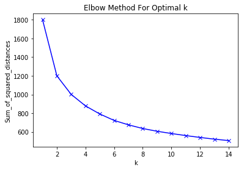

```python
from sklearn.preprocessing import MinMaxScaler
import matplotlib.pyplot as plt

mms = MinMaxScaler()
mms.fit(X_120)
data_transformed = mms.transform(X_120)

Sum_of_squared_distances = []
K = range(1,15)
for k in K:
    km = KMeans(n_clusters=k)
    km = km.fit(data_transformed)
    Sum_of_squared_distances.append(km.inertia_)

plt.plot(K, Sum_of_squared_distances, 'bx-')
plt.xlabel('k')
plt.ylabel('Sum_of_squared_distances')
plt.title('Elbow Method For Optimal k')
plt.show()
```

## We came, we saw, we clustered

Now we need to assign individual player matches into the cluster they always knew was home. We do this by using kmeans built in `predict` function. We then loop through each row of data and assign its cluster.

```python
#assign categories to all rows in the dataframe
predictions = kmeans_120.predict(X_120)
for index, row in data_120.iterrows():
    data_120.loc[index, "category"] = predictions[index]
```

### What a cluster?

One thing you should know about KMeans clustering is that it's a form of *unsupervised learning*. This is , as you might expect, in contrast to *supervised learning*, like the decision tree analysis. The difference is that in a supervised learning algorithm you are explicitly telling the algorithm what you want it to look for; in our case `win_status`. In a unsupervised learning algorithm the algorithm makes the associations on its own, without any of our help.

Why does this matter? Well, it's really more of a minor inconvenience. I've run this algorithm a quite a few times and the clusters tend to be more or less the same. The issue is that their corresponding number changes every time you run the algorithm. This means I can't directly assign the clever names I came up with because someone deciding to run this on their own computer would get a different outcome.

So I'd ask that you look at the data yourself and decide what attributes correspond to which categories. That being said, I have noticed 5-6 trends that tend to appear each time I run it and will give them now.

### The Categories

```python
data_120[["win_status", "kda", "final_match_level", "minutes", "surrendered", "objective_assists", "kill_participation"] + columns + ["category"]].groupby(by="category").mean().round(2)
```

| category | win_status | kda | final_match_level | minutes | surrendered | objective_assists | kill_participation | gold_per_minute | kills_player | deaths | assists | damage_mitigated | damage_taken | damage_player | structure_damage |
| --- | --- | --- | --- | --- | --- | --- | --- | --- | --- | --- | --- | --- | --- | --- | --- |
| 0.0 | 0.95 | 10.97 | 19.51 | 25.65 | 0.33 | 7.01 | 0.49 | 571.84 | 8.13 | 3.48 | 8.33 | 7,668.82 | 17,610.31 | 18,924.95 | 5,788.76 |
| 1.0 | 0.19 | 1.73 | 11.18 | 15.2 | 0.96 | 0.3 | 0.35 | 451.59 | 1.24 | 3.19 | 1.87 | 3,868.06 | 8,668.55 | 5,116.88 | 181.61 |
| 2.0 | 0.61 | 6.8 | 18.57 | 26.81 | 0.41 | 3.62 | 0.51 | 505.1 | 4.0 | 4.33 | 11.23 | 28,231.73 | 25,671.79 | 15,335.63 | 739.64 |
| 3.0 | 0.12 | 1.67 | 16.85 | 24.72 | 0.52 | 1.08 | 0.44 | 451.72 | 3.4 | 7.33 | 4.55 | 9,813.27 | 19,458.86 | 12,736.31 | 575.9 |
| 4.0 | 0.77 | 11.04 | 19.77 | 26.29 | 0.43 | 4.24 | 0.62 | 583.0 | 12.6 | 4.59 | 8.18 | 10,469.83 | 21,290.92 | 24,921.84 | 1,709.92 |
| 5.0 | 0.82 | 9.73 | 17.18 | 20.84 | 0.8 | 2.7 | 0.52 | 547.99 | 5.71 | 2.6 | 6.88 | 7,001.16 | 13,179.2 | 12,375.01 | 1,050.63 |
| 6.0 | 0.8 | 7.29 | 11.5 | 11.66 | 1.0 | 0.73 | 0.42 | 582.64 | 3.05 | 0.87 | 2.25 | 2,466.73 | 5,698.13 | 4,913.58 | 396.51 |

## The Parallel Plot is Afoot

Next we're displaying our categories graphically using a *parallel plot*. Instead of being displayed in absolute terms, they are compared relatively. So for our *Think, Tank* category damage mitigated will be very high, over 2 on the y-axis. This is not to say they mitigated 2 damage, but that it's high for this particular category.

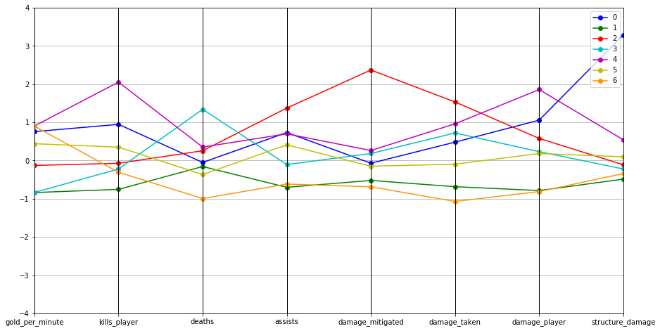

```python
parallel_plot(P_120)
```

## Who Belongs Where?

Finally, I've taken our data and broken it up by `god_name` and then by our new categories. The last column represents the proportion of games where that god fell into that category. This is to illustrate how each god might be played, but more importantly, in my mind, to show what types of players play each god. Many players have experienced games where another player might pick a particular god *(*cough* Loki *cough*)*, just to have that player get absolutely destroyed and have their incompetence ruin any chance you had at winning. So that's what this is.

```python
data_120[["category", "win_status", "god_name"]].groupby(by=["god_name", "category"]).count() / data_120[["win_status", "god_name"]].groupby(by=["god_name"]).count()
```

| god_name | category | win_status |
| --- | --- | --- |
| Achilles | 1.0 | 0.30201342281879195 |
|  | 2.0 | 0.20134228187919462 |
|  | 3.0 | 0.14093959731543623 |
|  | 4.0 | 0.06711409395973154 |
|  | 5.0 | 0.14093959731543623 |
|  | 6.0 | 0.1476510067114094 |
| Agni | 0.0 | 0.015625 |
|  | 1.0 | 0.25 |
|  | 3.0 | 0.1640625 |
|  | 4.0 | 0.1171875 |
|  | 5.0 | 0.1953125 |
|  | 6.0 | 0.2578125 |
| Ah Muzen Cab | 0.0 | 0.0967741935483871 |
|  | 1.0 | 0.3118279569892473 |
|  | 3.0 | 0.20430107526881722 |
|  | 4.0 | 0.043010752688172046 |
|  | 5.0 | 0.1827956989247312 |
|  | 6.0 | 0.16129032258064516 |
| Ah Puch | 0.0 | 0.010638297872340425 |
|  | 1.0 | 0.24468085106382978 |
|  | 2.0 | 0.02127659574468085 |
|  | 3.0 | 0.23404255319148937 |
|  | 4.0 | 0.05319148936170213 |
|  | 5.0 | 0.26595744680851063 |
|  | 6.0 | 0.1702127659574468 |
| Amaterasu | 1.0 | 0.35 |
|  | 2.0 | 0.2625 |
|  | 3.0 | 0.2 |
|  | 5.0 | 0.125 |
|  | 6.0 | 0.0625 |

[output cut: 471 more lines]

605 rows × 1 columns

## Thanks for reading!

So that's all I have right now. I hope you enjoyed it. I hope you use the data to improve your Smite game, or improve my grade (looking at you George). I plan on doing some more analysis in the future, probably something involving optimal builds. Anyway, thakns for reading!

*still waiting on profit